# R Assignment - Admission

GWU Intro to Data Science DATS 6101

2022-10-25

# HW Assignment - Estimation

This exercise uses the graduate school admissions dataset from the applicants to a higher-ed institute. The dataset is called `gradAdmit` on api.regression.fit, or as a local file `LogRegAdmit.csv`.  
The variables in the dataset are:

- `admit`: 0 or 1 (False or True)
- `gre`: gre score
- `gpa`: grade point average at undergraduate level
- `rank`: the ranking of the applicant’s undergraduate institute, 1, 2, 3, or 4

## Grad School Admissions

### Question 1

**After importing the dataset as Adata, check the structure. Make sure admit and rank are stored as factors, instead of numeric or integers. (Hint: Use as.factor() function or factor() function).**

```r
Adata <- data.frame(read.csv("LogRegAdmit.csv"))
Adata
str(Adata)
Adata$admit <- as.factor(Adata$admit)
Adata$rank <- as.factor(Adata$rank)
Adata
```

[output not shown]

### Question 2

**Construct t-intervals for the gre and gpa data for all applicants at 0.80 level and 0.99 level.**

```r
t_interval_gre_80 = t.test(x=Adata$gre, conf.level=0.80)
t_interval_gre_80
t_interval_gre_99 = t.test(x=Adata$gre, conf.level=0.99)
t_interval_gre_99
t_interval_gpa_80 = t.test(x=Adata$gpa, conf.level=0.80)
t_interval_gpa_80
t_interval_gpa_99 = t.test(x=Adata$gpa, conf.level=0.99)
t_interval_gpa_99
```

[output not shown]

### Question 3

**Repeat the same calculation for gre in Question 2 but for admitted (1) and rejected (0) separately. (You can subset them first.) Between the admitted and rejected, does the two intervals overlap at 0.80 level? And at 0.99 level?**

```r
admitted <- subset(Adata,admit==1)
rejected <- subset(Adata,admit==0)

t_interval_gre_80_rej = t.test(x=rejected$gre, conf.level=0.80)
t_interval_gre_80_rej
t_interval_gre_99_rej  = t.test(x=rejected$gre, conf.level=0.99)
t_interval_gre_99_rej
t_interval_gpa_80_rej  = t.test(x=rejected$gpa, conf.level=0.80)
t_interval_gpa_80_rej
t_interval_gpa_99_rej  = t.test(x=rejected$gpa, conf.level=0.99)
t_interval_gpa_99_rej

t_interval_gre_80_adm = t.test(x=admitted$gre, conf.level=0.80)
t_interval_gre_80_adm
t_interval_gre_99_adm = t.test(x=admitted$gre, conf.level=0.99)
t_interval_gre_99_adm
t_interval_gpa_80_adm = t.test(x=admitted$gpa, conf.level=0.80)
t_interval_gpa_80_adm
t_interval_gpa_99_adm = t.test(x=admitted$gpa, conf.level=0.99)
t_interval_gpa_99_adm
```

[output not shown]

### Question 4

**Make (box-) plots showing the gre distribution among applicants from different school rankings for the admitted and rejected separately. Please use ggplot for this. The x-variable should be rank, and the y-variable should be gre.**

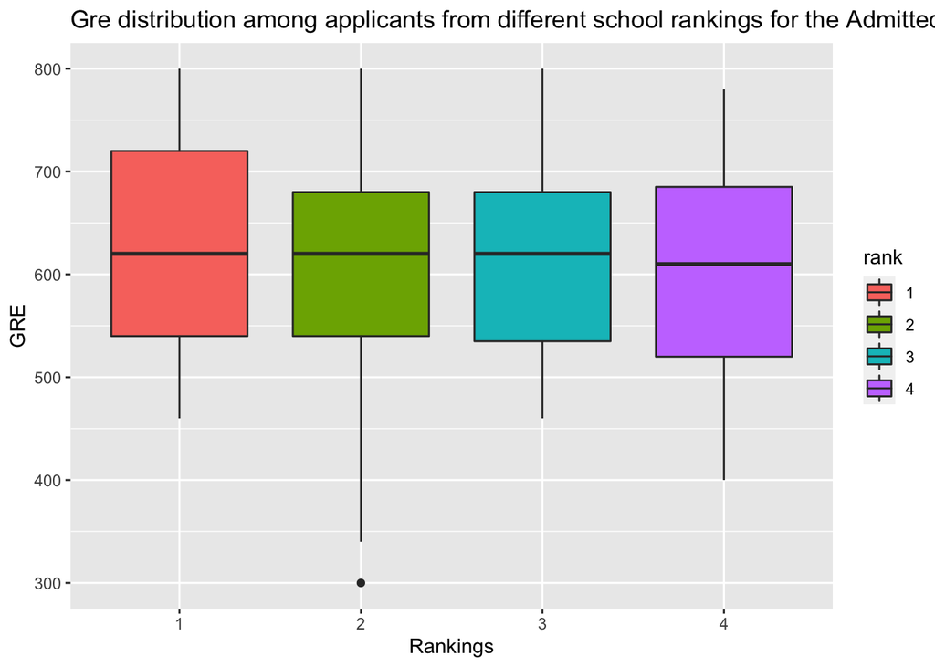

```r
loadPkg("ggplot2")
ggplot(admitted, aes(x=rank, y=gre, fill=rank)) +
  geom_boxplot() +
  labs(title="Gre distribution among applicants from different school rankings for the Admitted", x="Rankings", y = "GRE")
```

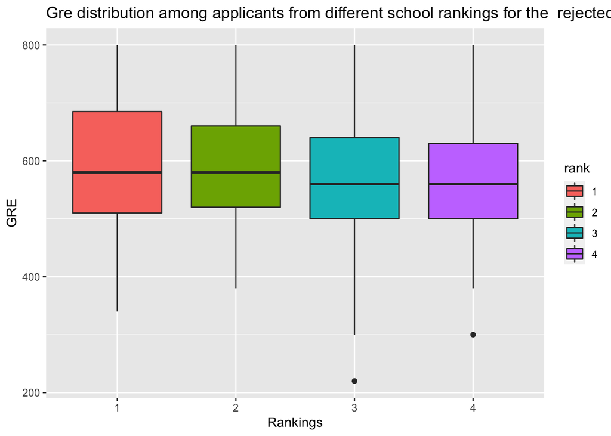

```r
loadPkg("ggplot2")
ggplot(rejected, aes(x=rank, y=gre, fill=rank)) +
  geom_boxplot() +
  labs(title="Gre distribution among applicants from different school rankings for the  rejected", x="Rankings", y = "GRE")
```

### Question 5

**Repeat Question 2 and Question 3 for gpa. Do the two groups have t-intervals overlap at 0.80 level? At 0.99 level?**

```r
t_interval_gpa_80 = t.test(x=Adata$gpa, conf.level=0.80)
t_interval_gpa_80
t_interval_gpa_99 = t.test(x=Adata$gpa, conf.level=0.99)
t_interval_gpa_99

t_interval_gpa_80_rej  = t.test(x=rejected$gpa, conf.level=0.80)
t_interval_gpa_80_rej
t_interval_gpa_99_rej  = t.test(x=rejected$gpa, conf.level=0.99)
t_interval_gpa_99_rej

t_interval_gpa_80_adm = t.test(x=admitted$gpa, conf.level=0.80)
t_interval_gpa_80_adm
t_interval_gpa_99_adm = t.test(x=admitted$gpa, conf.level=0.99)
t_interval_gpa_99_adm
```

[output not shown]

### Question 6

**Repeat Question 4 for gpa. Make (box-) plots showing the gpa distribution among applicants from different school rankings for the admitted and rejected separately. Again, use ggplot.**

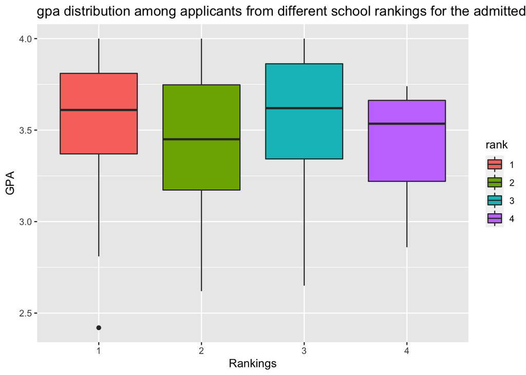

```r
ggplot(admitted, aes(x=rank, y=gpa, fill=rank)) +
  geom_boxplot( ) +
  labs(title="gpa distribution among applicants from different school rankings for the admitted", x="Rankings", y = "GPA")
```

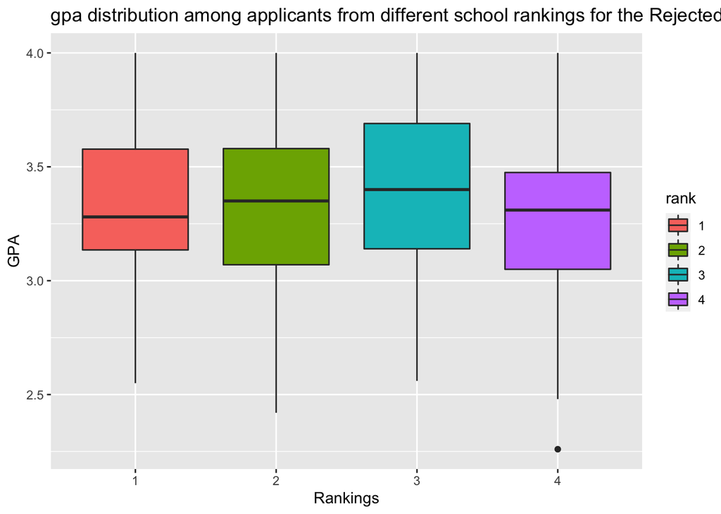

```r
ggplot(rejected, aes(x=rank, y=gpa, fill=rank)) +
  geom_boxplot( ) +
  labs(title="gpa distribution among applicants from different school rankings for the Rejected", x="Rankings", y = "GPA")
```

### Question 7

**As EDA from the charts and the t-interval calculations you produced, do you observe any potential effects between gre/gpa/rank on admissions? Explain briefly.**